# Gaussian process Regression

In this document, we give a brief illustration on Gaussian process regression (GPR) and also discuss the gaussian process functional regression (GPFR). The details about the (GPFR) are discussed in an other document. This document serves as a supplemental material for my AIMS’ essay and can be added to the chapter 3. Our motivation is to discuss quite broadly the GPR and GPFR, since it was not really done in the work. We also provide `R` and `python` codes to illustrative the theory.

## 1 An overview of Linear regression

### 1.1 Introduction

Several problems in the real world consists to learn about some quantities, say `y`, from the others, let’ say `x`, when there exists a proof of dependency of `y` on `x`. In the other words, given $x,y$ and the evidence that $y$ depends on $y$, we seek to know future values of $y$ given new values $x$. In statistical terms, this task is called **regression**. The dependency is expressed in mathematical notation is $f$, say

$$y=f(x)$$

When we are only able to know $y$ with some uncertainties, since we are not really sure, we can decide to include a term that expresses that randomness. That term is often referred to **white noise** and usually denoted by $\epsilon$ . Then we write

$$y=f(x)+\epsilon \tag{1}$$

Several assumptions can be made about the form of $f$, for instance, one can assume $f$ to be linear, non linear, smooth, etc. We consider the case where $f$ is linear.

### 1.2 Multivariate Linear Regression

Consider a dataset $\fm D=\{(\bs x_i, y_i)\mid i=1, \ldots, n\}$ a given dataset, where $\bs x_i$ is a $(d+1)-$ dimensional vector. The multivariate linear regression model (MLR) can be given as

$$y_i = f(\bs x_i) + \epsilon_i, i=1, \ldots, n, \text{ where } f(\bs x)= \bs x^T \bs \omega \tag{2} \label{2}$$

where $\bs \omega =(w_0, \ldots, w_d)$ a weight vector.

Using the matrix notation , we model for the $n$ observations can be written as

$$\left(\begin{array}{c}
y_1\\
y_2\\
\vdots\\
y_n
\end{array}\right)= \left(\begin{array}{cccc}
1 & x_{11} & \ldots & x_{1d}\\
1 & x_{21} & \ldots & x_{2d}\\
\vdots & \vdots& \ldots & \vdots\\
1 & x_{n1} & \ldots & x_{nd}
\end{array} \right)\left(\begin{array}{c}
\omega_1\\
\omega_2\\
\vdots\\
\omega_d
\end{array}\right)+ \left(\begin{array}{c}
\epsilon_1\\
\epsilon_2\\
\vdots\\
\epsilon_n
\end{array}\right) \;\; \text{ or } \bs y = \bs X \bs \omega + \bs \epsilon$$

The model $(\ref{2})$ bares the assumptions below:

- $\K E \epsilon_i =0, \; \forall i$
- $\K Var( \epsilon_i) i= \sigma^2, \forall i$
- $cov(\epsilon_i, \epsilon_j) = 0, \;\; \forall \; i, j$

With these assumptions, $\K E (\bs y) = \bs X \bs \omega$, and it is usually denoted as $\bs {\hat{y}}= \K E (\bs y)$. The main idea is to estimate the coefficients $\bs \omega$ from the dataset, we use the least square estimation (LSE) (see e.g. https://en.wikipedia.org/wiki/Least_squares) that consists to solve the problem

$$\text{find} \; \bs {\hat{\omega}} \text{ s.t } \bs {\hat{\omega}} = arg\min_{\bs \omega \in \K R^d} \sum_{i=1}^n \left( y_i-x_i^t w \right)^2 \tag{3} \label{3}$$

I results the estimate

$$\bs {\hat{\omega}} = \left(\bs X^T \bs X\right)^{-1} \bs X^T \bs y$$

where $y=(y_1, \ldots, y_n)$ .

For the LSE to work, the matrix $\bs X^T \bs X$ must be non singular. This occurs when $n> d+1$. Some facts can be establish. We can look at

- $\bs X^T \bs X$ as the covariance matrix for $\bs x_i$, multiplied by a proportionality constant.
- $\bs X^T \bs y$ as the cross-covariance of $\bs x$ and $\bs y$, multiplied by a proportionality constant.

If we denote $C_{xx}$ the covariance matrix of $\bs x$ and $\bs r_{xy}$ the cross-covariance matrix between $\bs x$ and $y$, it is remarkable that $\bs {\hat{\omega}}$ satisfies $C_{xy} \bs {\hat{\omega}}= \bs r_{xy}$, if and only if $C_{xx}$ is non singular. This equation is called the **normal least square population equation**.

Having the estimate for $\bs $, we have the model

$$\bs{\hat{y}}= \bs X \bs {\hat{\omega}}$$

### 1.3 Example of MLR using R

- Case $d=1$: Simple linear regression:

In this case, the model can be written as

$$y_i= \omega_0 + \omega_1 x_i+ \epsilon_i \tag{4}$$
The estimates for $\bs \omega$ is given as

$$\omega_0 = \overline{y}-\omega_1 \overline{x}
,\;\; \omega_1 = \frac{\sum_{i=1}^n\left( x_i-\overline{x}\right) \left(y_i-\overline{y} \right)}{\sum_{i=1}^n \left( x_i-\overline{x}\right)}$$

with $\fm D=\{(x_1, y_i)\mid i=1, \ldots, n \}$.

Illustration using R. One way is to use built-in methods to work with MLR or to implement it from scratch. We illustrate how to use built-in `R` methods.

Imports the packages below:

```r
library(ggplot2) #for nice plots
library(datasets)## for datasets
#library(carData) ## for datasets
#library(car)# for built-in datasets
library(ISLR2)
```

```r
names(Boston) ## Displays the column of the datasets
```

```
 [1] "crim"    "zn"      "indus"   "chas"    "nox"     "rm"      "age"
 [8] "dis"     "rad"     "tax"     "ptratio" "lstat"   "medv"
```

```r
head(Boston) ## displays the first 5 rows
```

```
     crim zn indus chas   nox    rm  age    dis rad tax ptratio lstat medv
1 0.00632 18  2.31    0 0.538 6.575 65.2 4.0900   1 296    15.3  4.98 24.0
2 0.02731  0  7.07    0 0.469 6.421 78.9 4.9671   2 242    17.8  9.14 21.6
3 0.02729  0  7.07    0 0.469 7.185 61.1 4.9671   2 242    17.8  4.03 34.7
4 0.03237  0  2.18    0 0.458 6.998 45.8 6.0622   3 222    18.7  2.94 33.4
5 0.06905  0  2.18    0 0.458 7.147 54.2 6.0622   3 222    18.7  5.33 36.2
6 0.02985  0  2.18    0 0.458 6.430 58.7 6.0622   3 222    18.7  5.21 28.7
```

```r
tail(Boston) ## displays the 5 last rows
```

```
       crim zn indus chas   nox    rm  age    dis rad tax ptratio lstat medv
501 0.22438  0  9.69    0 0.585 6.027 79.7 2.4982   6 391    19.2 14.33 16.8
502 0.06263  0 11.93    0 0.573 6.593 69.1 2.4786   1 273    21.0  9.67 22.4
503 0.04527  0 11.93    0 0.573 6.120 76.7 2.2875   1 273    21.0  9.08 20.6
504 0.06076  0 11.93    0 0.573 6.976 91.0 2.1675   1 273    21.0  5.64 23.9
505 0.10959  0 11.93    0 0.573 6.794 89.3 2.3889   1 273    21.0  6.48 22.0
506 0.04741  0 11.93    0 0.573 6.030 80.8 2.5050   1 273    21.0  7.88 11.9
```

To have broad details of the columns names, I mean their significations, you just need to use

```r
help("Boston")
```

This shows for instance that the column `crim` records per capita crime rate by town, `medv` records the median value of owner-occupied homes in $1000s. You can get the overall summary the dataset using

```r
summary(Boston)
```

```
      crim                zn             indus            chas
 Min.   : 0.00632   Min.   :  0.00   Min.   : 0.46   Min.   :0.00000
 1st Qu.: 0.08205   1st Qu.:  0.00   1st Qu.: 5.19   1st Qu.:0.00000
 Median : 0.25651   Median :  0.00   Median : 9.69   Median :0.00000
 Mean   : 3.61352   Mean   : 11.36   Mean   :11.14   Mean   :0.06917
 3rd Qu.: 3.67708   3rd Qu.: 12.50   3rd Qu.:18.10   3rd Qu.:0.00000
 Max.   :88.97620   Max.   :100.00   Max.   :27.74   Max.   :1.00000
      nox               rm             age              dis
 Min.   :0.3850   Min.   :3.561   Min.   :  2.90   Min.   : 1.130
 1st Qu.:0.4490   1st Qu.:5.886   1st Qu.: 45.02   1st Qu.: 2.100
 Median :0.5380   Median :6.208   Median : 77.50   Median : 3.207
 Mean   :0.5547   Mean   :6.285   Mean   : 68.57   Mean   : 3.795
 3rd Qu.:0.6240   3rd Qu.:6.623   3rd Qu.: 94.08   3rd Qu.: 5.188
 Max.   :0.8710   Max.   :8.780   Max.   :100.00   Max.   :12.127
      rad              tax           ptratio          lstat
 Min.   : 1.000   Min.   :187.0   Min.   :12.60   Min.   : 1.73
 1st Qu.: 4.000   1st Qu.:279.0   1st Qu.:17.40   1st Qu.: 6.95
 Median : 5.000   Median :330.0   Median :19.05   Median :11.36
 Mean   : 9.549   Mean   :408.2   Mean   :18.46   Mean   :12.65
 3rd Qu.:24.000   3rd Qu.:666.0   3rd Qu.:20.20   3rd Qu.:16.95
 Max.   :24.000   Max.   :711.0   Max.   :22.00   Max.   :37.97
      medv
 Min.   : 5.00
 1st Qu.:17.02
 Median :21.20
 Mean   :22.53
 3rd Qu.:25.00
 Max.   :50.00
```

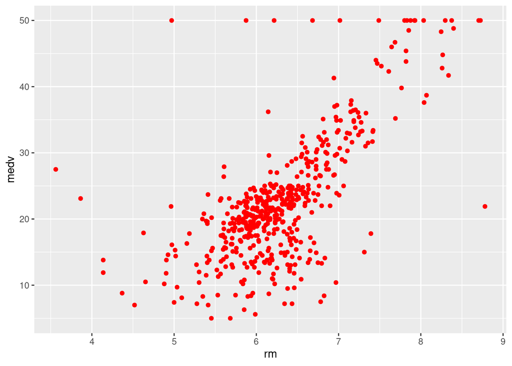

```r
fix(Boston)  ## Fix the dataset, you can also use attach.
gg1<- ggplot(data = Boston, aes(x=rm, y=medv))+
  geom_point(colour="red")
gg1
```

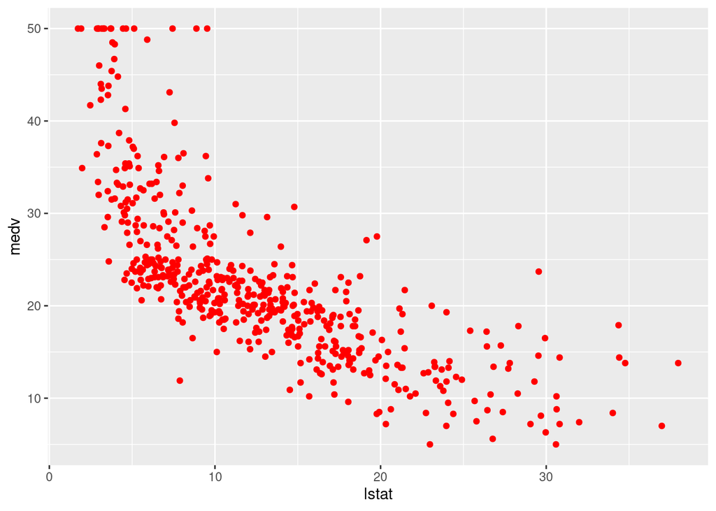

```r
gg2<- ggplot(data = Boston, aes(x=lstat, y=medv))+
  geom_point(colour="red")
gg2
```

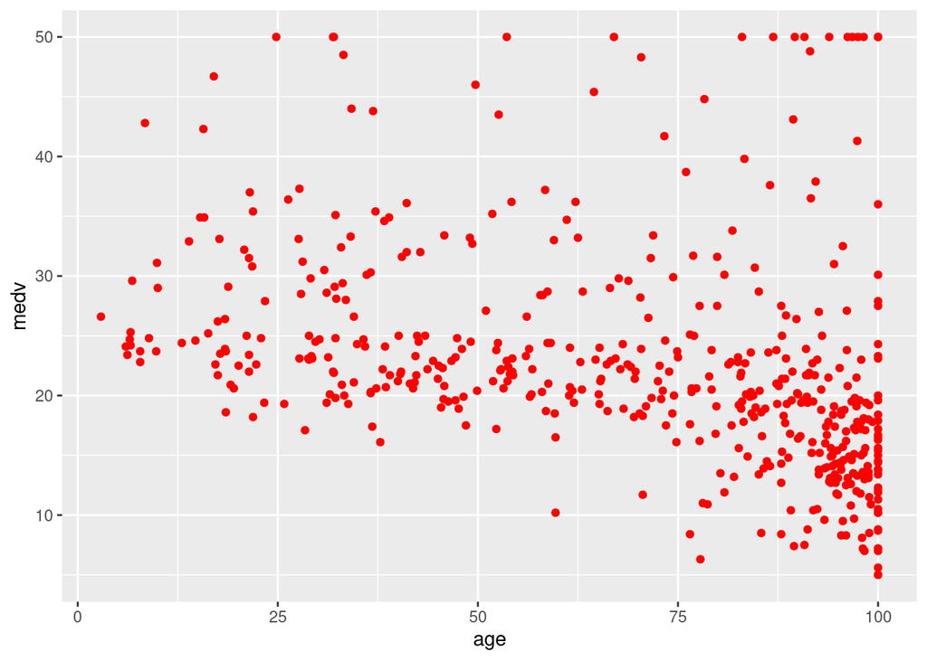

```r
gg3<- ggplot(data = Boston, aes(x=age, y=medv))+
  geom_point(colour="red")
gg3
```